# 03_Main_Analysis

Dupret Florent

2024-06-01

# 1 Context

Goal of this document: evaluate association between metabolomic profile and bacterial composition. Data: preprocessed metabolite peak intensities and preprocessed relative abundance of bacterial species. Data structure: within (temporal) and between subject correlation present (all other correlations were discarded or adjusted for, except maybe the size effect)

```r
STAN <- readRDS("../05_Results/PreprocessedSTANFORD_mae.Rds")
UMD <- readRDS("../05_Results/PreprocessedUMD_mae.Rds")
```

For the following analysis, if necessary, we will limit the number of variables (or latent variables) to the arbitrary number of $50$. For example, in an eventual PCA, we can manually choose to summarize the data on the first 50 principal components.

```r
#Number of max variables (or latent variables)
nvar <- 50
```

# 2 Data analysis

To measure and visualize associations between datatables, we can use a series of methods. In this document, we perform STATIS analysis, Simultaneous component analysis, and canonical correlation analysis. Once again, we will perform the analysis separately for Stanford and UMD samples.

But first, let us detail the notation to use to explain the three types of analysis: STATIS analysis, simultaneous component analysis (SCA), and canonical correlation analysis (CCA).

- Let the number of datatables be $k=1,...,K$. In our case, $K=2$ because we have the metabolite table (let us call it $X_{k=1}$) and the compositional table (let us call it $X_{k=2}$). In the following paragraphs, we will refer to the tables $X_k$ either as “tables”, “blocks”, or “block matrices”.
- The dimensions of the block matrices are $n_k \times p_k$
- The following analysis rely on “common-row” blocks with different variables, meaning the observations of the blocks must be identical. Indeed, both metabolite and composition tables share the same samples (from the same 80 women). Therefore, we can write $n_1 = n_2 = n$ and simplify the dimensions of the blocks to $n \times p_k$

We note that, because we filtered samples in the metabolite preprocessing, we must match the remaining samples in the compositional data. This has as a consequence some information losses. Here are the dimensions and structure of both block matrices for Stanford and UMD:

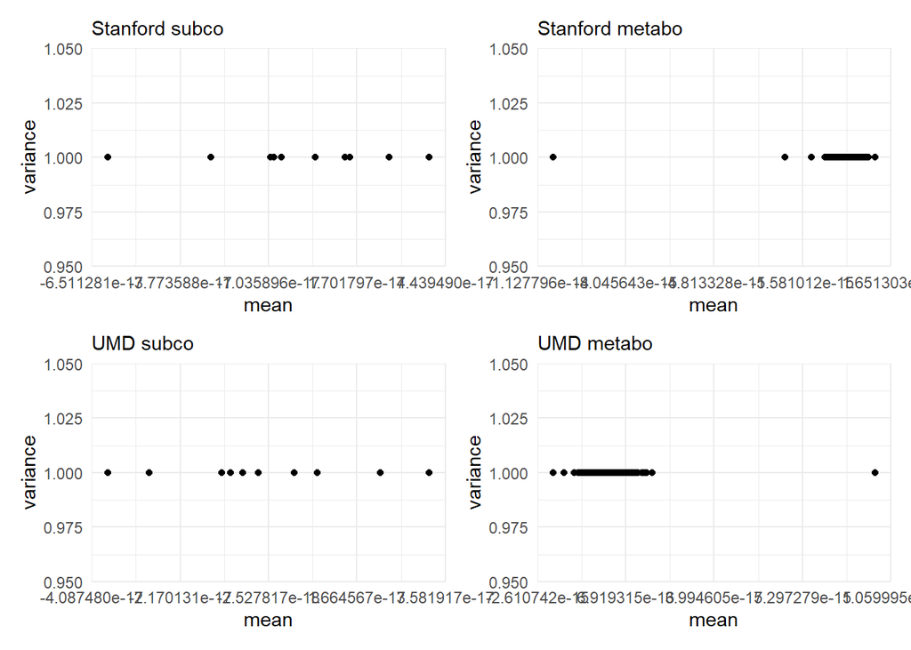

```r
#Defining datasets
#MB.SE.stan <- STAN[["MB_clean"]]
MB.SE.stan <- STAN[["MB_filt_imp_trans_Batch"]] #Will yield other results
VM.SE.stan <- STAN[["c_topics_16S_10"]]
#MB.SE.umd <- UMD[["MB_clean"]]
MB.SE.umd <- UMD[["MB_filt_imp_trans"]] #Will yield other results
VM.SE.umd <- UMD[["c_topics_16S_10"]]
#Keeping only matching samples
MB.SE.stan <- MB.SE.stan[,colnames(MB.SE.stan) %in% colnames(VM.SE.stan)]
VM.SE.stan <- VM.SE.stan[,colnames(VM.SE.stan) %in% colnames(MB.SE.stan)]
MB.SE.umd <- MB.SE.umd[,colnames(MB.SE.umd) %in% colnames(VM.SE.umd)]
VM.SE.umd <- VM.SE.umd[,colnames(VM.SE.umd) %in% colnames(MB.SE.umd)]
#Extracting assay data
VM.stan <- t(assay(VM.SE.stan)) |>
  scale(center = T, scale = T)
MB.stan <- t(assay(MB.SE.stan)) |>
  scale(center = T, scale = T)
VM.umd <- t(assay(VM.SE.umd)) |>
  scale(center = T, scale = T)
MB.umd <- t(assay(MB.SE.umd)) |>
  scale(center = T, scale = T)
#Mean-variance
(ggplot()+aes(y = apply(VM.stan, MARGIN = 2, FUN = var),
             x = apply(VM.stan, MARGIN = 2, FUN = mean))+
  geom_point()+
  labs(x = "mean", y = "variance",
       subtitle = "Stanford subco") +
  ggplot()+aes(y = apply(MB.stan, MARGIN = 2, FUN = var),
             x = apply(MB.stan, MARGIN = 2, FUN = mean))+
  geom_point()+
  labs(x = "mean", y = "variance",
       subtitle = "Stanford metabo"))/
  (ggplot()+aes(y = apply(VM.umd, MARGIN = 2, FUN = var),
             x = apply(VM.umd, MARGIN = 2, FUN = mean))+
  geom_point()+
  labs(x = "mean", y = "variance",
       subtitle = "UMD subco") +
  ggplot()+aes(y = apply(MB.umd, MARGIN = 2, FUN = var),
             x = apply(MB.umd, MARGIN = 2, FUN = mean))+
  geom_point()+
  labs(x = "mean", y = "variance",
       subtitle = "UMD metabo"))+
  plot_layout(guides = "collect")
```

```r
#Block scaling
#(VM.stan/ncol(VM.stan)) |> apply(MARGIN = 2, FUN = sd)
VM.stan <- (VM.stan/ncol(VM.stan)) #|> data.frame(check.names = F)
MB.stan <- (MB.stan/ncol(MB.stan)) #|> data.frame(check.names = F)
VM.umd <- (VM.umd/ncol(VM.umd)) #|> data.frame(check.names = F)
MB.umd <- (MB.umd/ncol(MB.umd)) #|> data.frame(check.names = F)
```

```r
paste("Dimension of Stanford metabolite data is ", dim(MB.stan)[1], "x", dim(MB.stan)[2])
paste("Dimension of Stanford compositional data is ", dim(VM.stan)[1], "x", dim(VM.stan)[2])
paste("Dimension of UMD metabolite data is ", dim(MB.umd)[1], "x", dim(MB.umd)[2])
paste("Dimension of UMD compositional data is ", dim(VM.umd)[1], "x", dim(VM.umd)[2])
```

```
## [1] "Dimension of Stanford metabolite data is  191 x 132"
## [1] "Dimension of Stanford compositional data is  191 x 10"
## [1] "Dimension of UMD metabolite data is  200 x 165"
## [1] "Dimension of UMD compositional data is  200 x 10"
```

## 2.1 STATIS analysis

STATIS analysis, or “Structuration des Tableaux A Trois Indices de la Statistique” is a method founded by L’Hermier Des Plantes H. (1976) to initially study the existing associations between $K$ datatables with the following characteristics: $n$ common observations of $p$ common variables, measured $K$ different times. The main idea was to infer the *trajectory* or *situations* of these $n$ individuals over time. To make such inference, L’Hermier Des Plantes though of making a *compromise* of all $K$ situations.

In a way, STATIS method is similar to principal component analysis, in the sense that it finds latent (compromised) variables with the highest variability across situations. However, a novel but key element to this PCA is the consideration of the weight for each situation.

The STATIS method can be considered in three steps:

*First step (Interstructure)*:

- Compute the similarity matrix $S_k = X_k X_k'$ for $k=1,...,K$ (one may recall that these similarity matrices are the backbone of the standard PCA)
- Compute the $K \times K$ matrix $\mathcal{S}$ as a “combination” of the K $S_k$ matrices such that $\mathcal{S}_{kl}$ is $\text{trace}(S_k S_l)$:

$$\mathcal{S} = \Big(
\big[\text{trace}(S_k S_l) \big]_{kl} \Big)_{k=1,...,K;
l=1,...,K}$$

*Second step (Compromise)*:

*Third step (Intrastructure)*:

According to [Van Deun, K. et.al](https://link.springer.com/article/10.1186/1471-2105-10-246?utm_source=getftr&utm_medium=getftr&utm_campaign=getftr_pilot#Bib1), the STATIS model can be written as an optimization problem of

$$\arg \min_{T,P_k} W^{(1)}_k
\sum_{k=1}^{K} \|X_k - TP_k' \|^2$$

where $W^{(1)}_k$ is the $k^{\text{th}}$ element of the eigenvector of matrix $\mathcal{S}$, $X_k$ is the $k^{\text{th}}$ block matrix, and $T$ and $P_k$ are the scores matrix and loadings matrix, respectively, of the principal component decomposition of $X_k$ (such that $X_k = T P_k' + E_k$). One may notice that the loadings matrix, unlike the scores matrix, is block-dependent. It is because the $n$ individuals are the same across data tables.

### 2.1.1 Variance decomposition

```r
ktabs.stan <- ktab.list.df(obj = list(Metabolite = as.data.frame(MB.stan),
                                 Subcommunity = as.data.frame(VM.stan)))
summary(ktabs.stan) |> pander()
ktabs.umd <- ktab.list.df(obj = list(Metabolite = as.data.frame(MB.umd),
                                 Subcommunity = as.data.frame(VM.umd)))
summary(ktabs.umd) |> pander()
```

|  | Length | Class | Mode |
| --- | --- | --- | --- |
| **Metabolite** | 132 | data.frame | list |
| **Subcommunity** | 10 | data.frame | list |
| **blo** | 2 | -none- | numeric |
| **lw** | 191 | -none- | numeric |
| **cw** | 142 | -none- | numeric |
| **TL** | 2 | data.frame | list |
| **TC** | 2 | data.frame | list |
| **T4** | 2 | data.frame | list |
| **call** | 2 | -none- | call |

|  | Length | Class | Mode |
| --- | --- | --- | --- |
| **Metabolite** | 165 | data.frame | list |
| **Subcommunity** | 10 | data.frame | list |
| **blo** | 2 | -none- | numeric |
| **lw** | 200 | -none- | numeric |
| **cw** | 175 | -none- | numeric |
| **TL** | 2 | data.frame | list |
| **TC** | 2 | data.frame | list |
| **T4** | 2 | data.frame | list |
| **call** | 2 | -none- | call |

Easily enough, all the results of the statis analysis are summarized in the plot below:

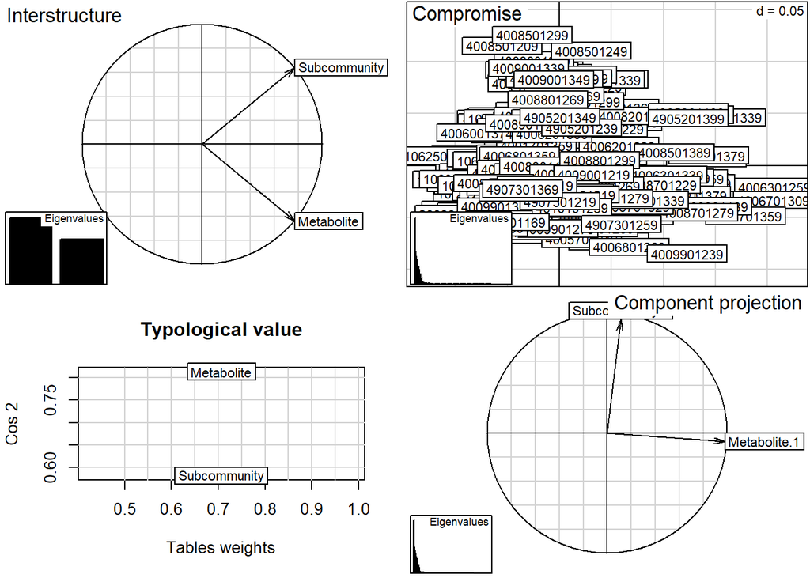

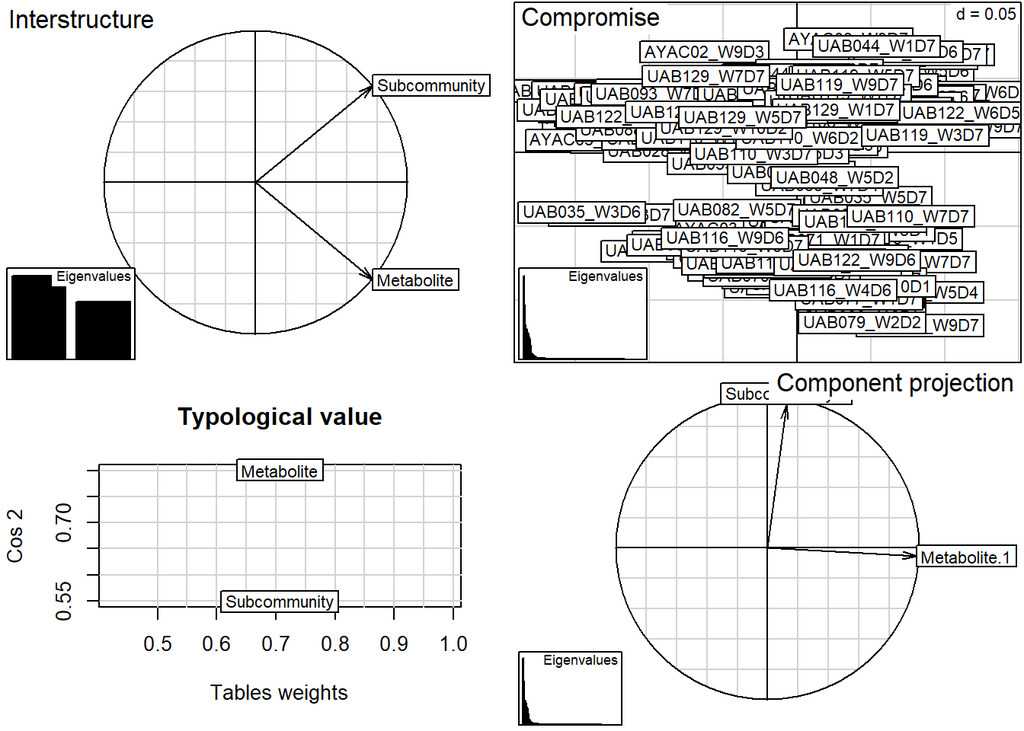

```r
statis.stan <- ade4::statis(X = ktabs.stan, scannf = FALSE, nf = 4)
statis.umd <- ade4::statis(X = ktabs.umd, scannf = FALSE, nf = 4)
plot(statis.stan, cex = 0.3)
plot(statis.umd, cex = 0.3)
```

Since the previous results are quite ugly and poorly represented, I make my own plots.

First, we verify the matrices were given the same weight $[W^{(1)}_k]_{k=1,2}$

```r
#Manual weight computation
weight <- function(MBmat, VMmat){
  n <- nrow(MBmat)

  #Rescaling matrices by the sqrt of the column standard deviation
  MB <- t(t(MBmat)*sqrt(apply(MBmat, 2, FUN = sd)))
  VM <- t(t(VMmat)*sqrt(apply(VMmat, 2, FUN = sd)))

  #Similarity matrices
  Smb <- as.matrix(MB) %*% t(as.matrix(MB))
  Ssc <- as.matrix(VM) %*% t(as.matrix(VM))

  #Matrix S
  S <- matrix(unlist(list(Smb, Ssc)), n*n, 2)
  #Raw RV matrix
  RVraw <- t(S) %*% S
  #sqrt of diag of RVraw
  ak <- sqrt(diag(RVraw))

  #"Standardising" RV coef
  RV <- sweep(RVraw, 1, ak, "/")
  RV <- sweep(RV, 2, ak, "/")
  #Eigendecomposition
  eig <- eigen(RV, symmetric = T)$vector

  weights <- data.frame(sigma = abs(ak), W1 = abs(eig[,1]))
  return(weights)
}
```

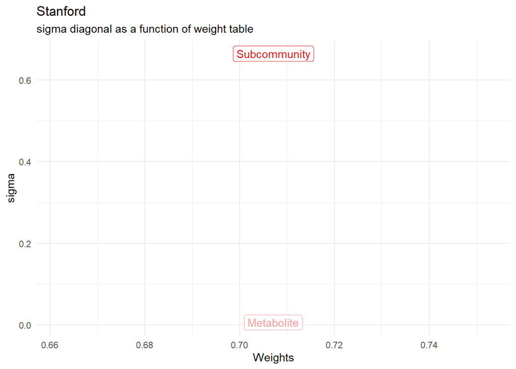

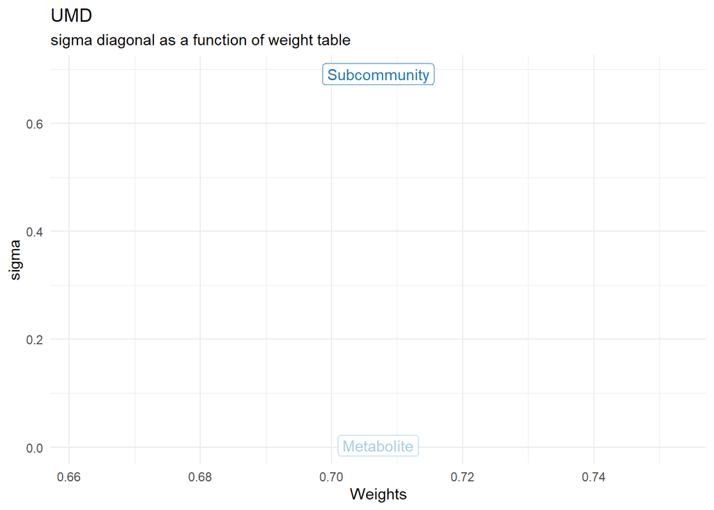

```r
#Stanford
tibble(
  Set = statis.stan$tab.names,
  Weights = weight(MB.stan, VM.stan)$W1,
  sigma = weight(MB.stan, VM.stan)$sigma) |>
  ggplot()+
  aes(x = Weights, y = sigma, label = Set, col = Set)+
  geom_label()+
  scale_color_manual(values = Dcol$Stanford, aesthetics = c("colour", "fill"))+
  labs(title = "Stanford",
       subtitle = "sigma diagonal as a function of weight table")+
  theme(legend.position = "none")
#UMD
tibble(
  Set = statis.umd$tab.names,
  Weights = weight(MB.umd, VM.umd)$W1,
  sigma = weight(MB.umd, VM.umd)$sigma) |>
  ggplot()+
  aes(x = Weights, y = sigma, label = Set, col = Set)+
  geom_label()+
  scale_color_manual(values = Dcol$UMD, aesthetics = c("colour", "fill"))+
  labs(title = "UMD",
       subtitle = "sigma diagonal as a function of weight table")+
  theme(legend.position = "none")
```

```r
cbind(Cohort = c(rep("Stanford", 2), rep("UMD", 2)),
      rbind(weight(MB.stan, VM.stan), weight(MB.umd, VM.umd))) |>
  tibble() |> mutate(Weight = W1/sigma) |>
  pander(caption = "Weights")
```

Weights

| Cohort | sigma | W1 | Weight |
| --- | --- | --- | --- |
| Stanford | 0.006362 | 0.7071 | 111.2 |
| Stanford | 0.6645 | 0.7071 | 1.064 |
| UMD | 0.003258 | 0.7071 | 217 |
| UMD | 0.691 | 0.7071 | 1.023 |

Indeed, both “Metabo” and “Subc” have the same weight of 0.7071068 and 0.7071068 for Stanford and UMD respectively (x-axis), which is the square root of the inverse of the number of datasets (i.e. $\sqrt{1/2}$)

In the Monte-Carlo simulations, the rows of each datatables are permuted randomly and the total inertia of the tables is computed. This inertia is the sum of all eigenvalues of the co-inertia analysis (i.e. an analysis aiming to find pairs of linear combinations $U$ and $V$ of the datasets’ variables which maximize covariance: $cov(U_i, V_i) = cor(U_i, V_i) \sqrt{var(U_i) var(V_i)}$), “that is the sum of the covariances between successive pairs of axes”. Through the permutation, the simulation may build the distribution of the inertia. The pvalue of the test is given by the frequency of observing the inertia value of the original datasets. [article](https://www.documentation.ird.fr/hor/fdi:010014295)

The function texttt{statis} also computes an RV coefficient: here is the comparison:

A minimum of 5000 permutations were applied to compute test significance

```r
rtest(MB.stan, VM.stan, MB.umd, VM.umd)
data.frame(RV.coef = c(statis.stan$RV[1,2], statis.umd$RV[1,2]),
           row.names = c("Stanford","UMD")) |> pander(caption = "RV coefficient between metabolite and compositional datasets using `statis` function for Stanford and UMD cohorts")
```

RV coefficient estimate and pvalue using Monte Carlo test

| Cohort | estimate | pvalue |
| --- | --- | --- |
| Stanford | 0.1855 | 2e-04 |
| UMD | 0.1823 | 2e-04 |

RV coefficient between metabolite and compositional datasets using `statis` function for Stanford and UMD cohorts

|  | RV.coef |
| --- | --- |
| **Stanford** | 0.1855 |
| **UMD** | 0.1823 |

As we can see, the RV coefficients are the same whether one uses the explicit texttt{RV.rtest} function or the implicit output of the function. However, the first result also gives a significance level of observing such a coefficient. In this case, the pvalue is below the threshold of 0.05, thus indicating a coefficient greater than 0. Therefore, we can be sure there is an association between the metabolite and compositional data.

Another approach to visualize the RV coefficient is to compute the cosine of the angle between the table vectors in the interstructure plot:

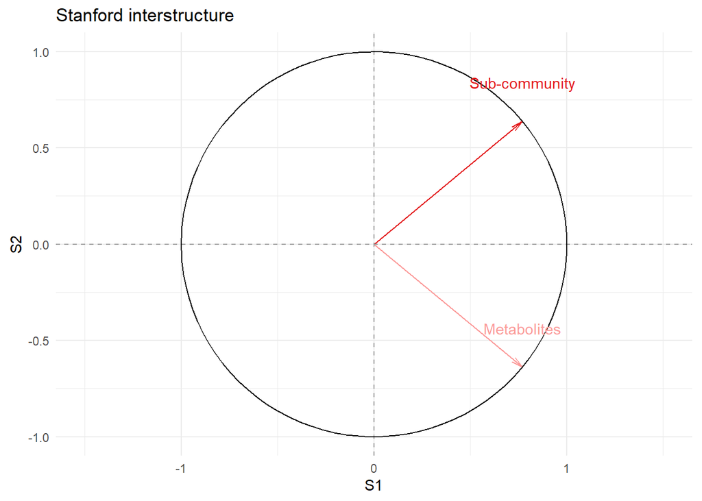

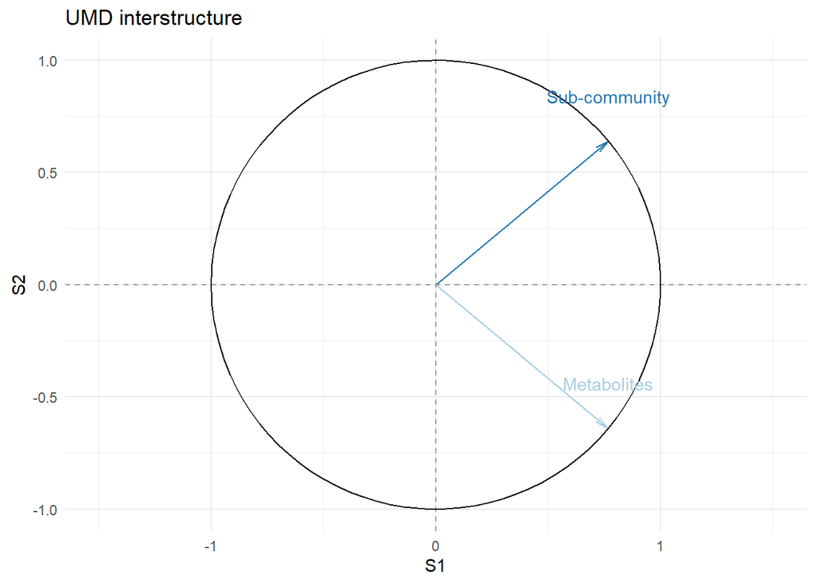

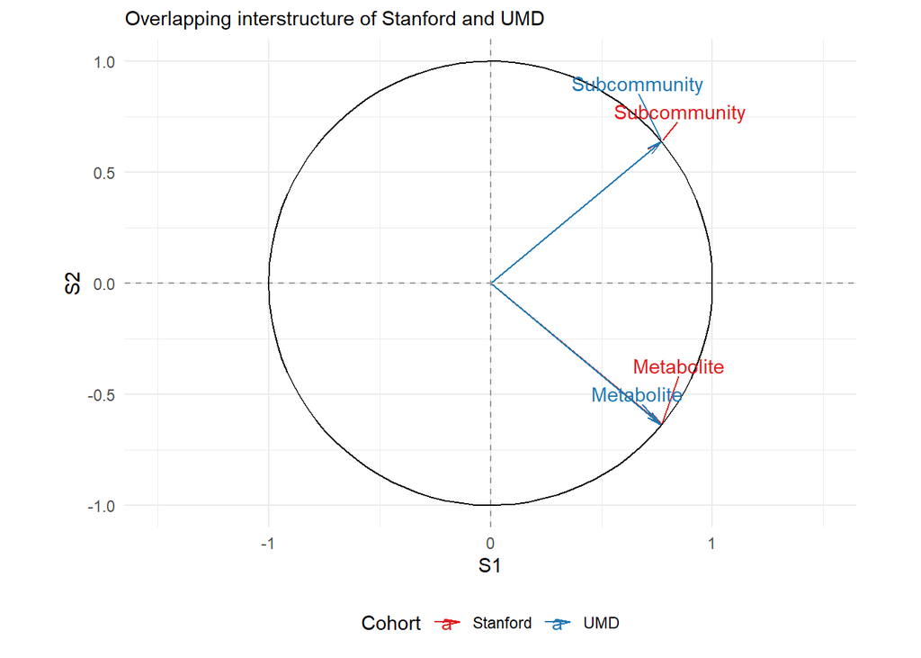

```r
Interstructure(statis.stan$RV.coo, Dcol = Dcol$Stanford, cohort = "Stanford")
Interstructure(statis.umd$RV.coo, Dcol = Dcol$UMD, cohort = "UMD")
##### Both interstructure on the same graph (because the values are standardised)
tibble(Cohort = "Stanford",
       block = rownames(statis.stan$RV.coo),
       statis.stan$RV.coo) |>
  rbind(tibble(Cohort = "UMD",
               block = rownames(statis.umd$RV.coo),
               statis.umd$RV.coo)) |>
  ggplot()+
  aes(xend = S1, yend = S2, x = 0, y = 0, col = Cohort)+
  geom_segment(arrow = arrow(angle = 12, length = unit(0.3, "cm")))+
  scale_fill_manual(values = c(unlist(Dcol[2,])), aesthetics = c("colour", "fill"))+
  geom_vline(aes(xintercept = 0),
             linetype = "dashed", col = "grey60")+
  geom_hline(aes(yintercept = 0),
             linetype = "dashed", col = "grey60")+
  #Drawing a circle:
  annotate("path", x = 0 + 1*cos(seq(0,2*pi,length.out=100)),
           y= 0 + 1*sin(seq(0,2*pi,length.out=100)))+
  coord_fixed(ratio = 1, xlim = c(-1.5,1.5))+
  geom_text_repel(aes(label = block, x = S1, y = S2), nudge_y = 0.2)+
  labs(x = "S1", y = "S2", subtitle = "Overlapping interstructure of Stanford and UMD")+
  theme(legend.position = "bottom")
```

As we can see, both table vectors are highly correlated with the first dimension, indicating a certain proximity or “similarity” between the two tables. Moreover, the magnitude of the vectors (their norm) is 1, meaning they both contribute 100% to the compromise. This value of 100% is not accidental: when the number of data blocks to compare is equal to $2$, the dimension of $\mathcal{S}$ is $2\times2$ and therefore there can only be a maximum of 2 components. Hence, the total variance is captured by the first and only two components.

I can also represent my datatables in the compromise’ principal component subspace (called the intrastructure). To do so, I must first inspect the explained variance in the compromise principal components. Therefore, we can look at the variance decomposition (based on the computation of eigenvalues):

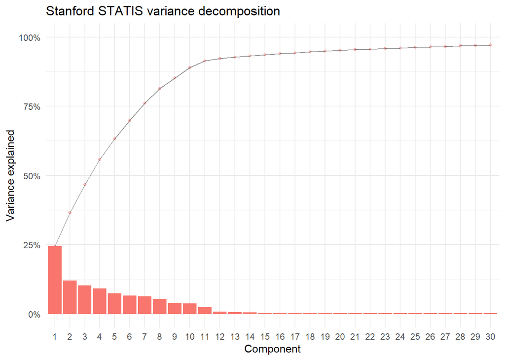

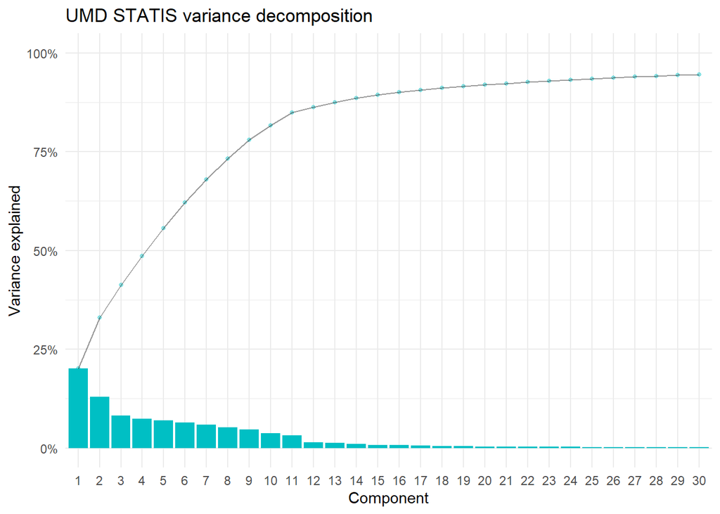

```r
eigentable.stan <- tibble(eigen = statis.stan$C.eig) |>
    mutate(perc.var = eigen/sum(eigen)) |>
    mutate(cum = cumsum(perc.var),
           comp = factor(1:length(eigen)))
eigentable.umd <- tibble(eigen = statis.umd$C.eig) |>
    mutate(perc.var = eigen/sum(eigen)) |>
    mutate(cum = cumsum(perc.var),
           comp = factor(1:length(eigen)))

scree(eigentable.stan[1:30,], cohort = "Stanford", col = CohCol["Stanford"])
scree(eigentable.umd[1:30,], cohort = "UMD", col = CohCol["UMD"])
```

The first principal component explains 24.5% of the variance in Stanford and 20.1% in UMD. The first two components capture 36.5% of the variance in Stanford and 33.1% in UMD. Furthermore, we require 7 components to reach 75% of variance explained in Stanford, but 9 components in UMD.

### 2.1.2 Intrastructure

Now I can explore the representation of my data blocks in the compromise’axis:

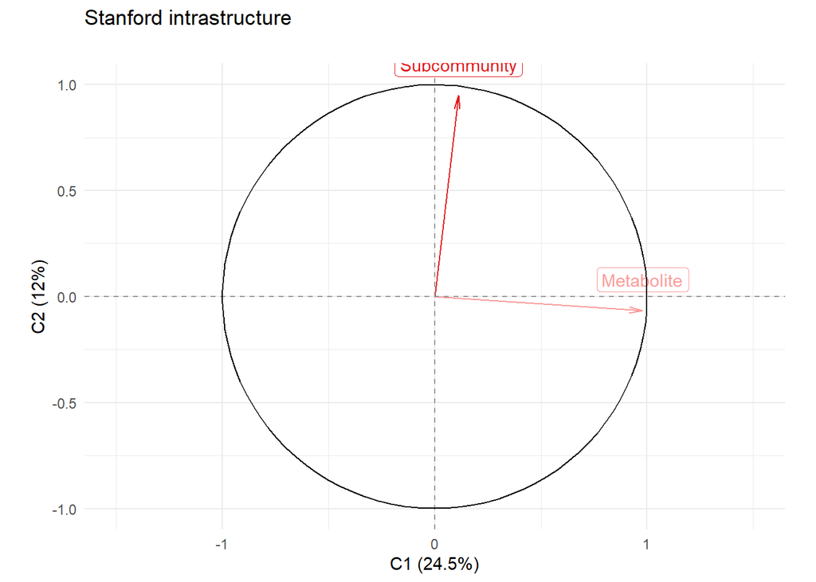

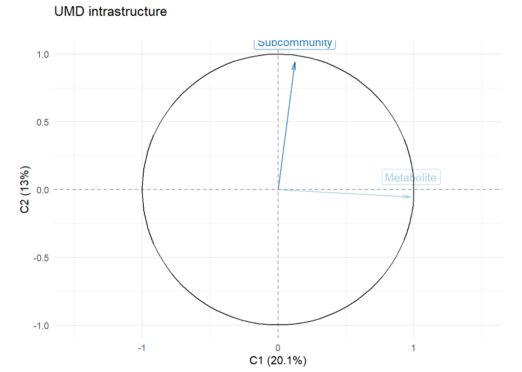

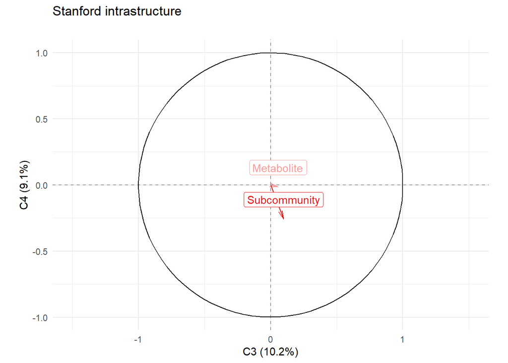

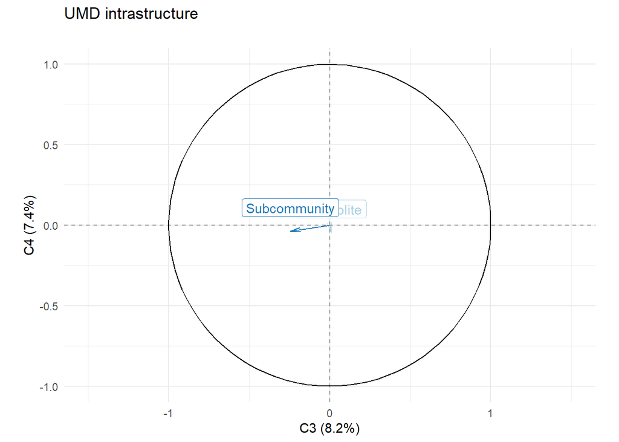

```r
Intrastructure(C.T4 = statis.stan$C.T4, comp = c(1,2), level = 1,
               eigentable = eigentable.stan,
               palette = Dcol$Stanford, cohort = "Stanford")
Intrastructure(C.T4 = statis.umd$C.T4, comp = c(1,2), level = 1,
               eigentable = eigentable.umd,
               palette = Dcol$UMD, cohort = "UMD")
Intrastructure(C.T4 = statis.stan$C.T4, comp = c(3,4), level = 1,
               eigentable = eigentable.stan,
               palette = Dcol$Stanford, cohort = "Stanford")
Intrastructure(C.T4 = statis.umd$C.T4, comp = c(3,4), level = 1,
               eigentable = eigentable.umd,
               palette = Dcol$UMD, cohort = "UMD")
```

Let us focus on the representation of the individuals on the compromise dimensions (the “row coordinates”):

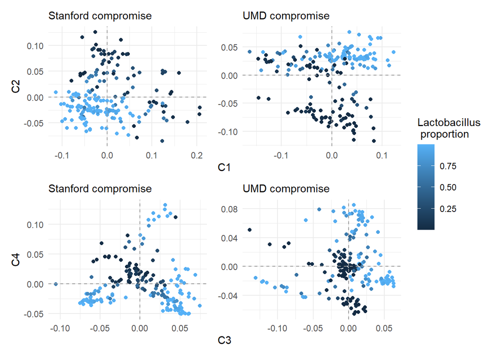

```r
ggplot(statis.stan$C.li)+
  aes(x = C1, y = C2, col = MB.SE.stan$Prop_Lacto)+
  geom_point()+
  geom_vline(aes(xintercept = 0),
             linetype = "dashed", col = "grey60")+
  geom_hline(aes(yintercept = 0),
             linetype = "dashed", col = "grey60")+
  labs(subtitle = paste0("Stanford", " compromise"),
       col = "Lactobacillus \n proportion") +
ggplot(statis.umd$C.li)+
  aes(x = C1, y = C2, col = MB.SE.umd$Prop_Lacto)+
  geom_point()+
  geom_vline(aes(xintercept = 0),
             linetype = "dashed", col = "grey60")+
  geom_hline(aes(yintercept = 0),
             linetype = "dashed", col = "grey60")+
  labs(subtitle = paste0("UMD", " compromise"),
       col = "Lactobacillus \n proportion")+
ggplot(statis.stan$C.li)+
  aes(x = C3, y = C4, col = MB.SE.stan$Prop_Lacto)+
  geom_point()+
  geom_vline(aes(xintercept = 0),
             linetype = "dashed", col = "grey60")+
  geom_hline(aes(yintercept = 0),
             linetype = "dashed", col = "grey60")+
  labs(subtitle = paste0("Stanford", " compromise"),
       col = "Lactobacillus \n proportion") +
ggplot(statis.umd$C.li)+
  aes(x = C3, y = C4, col = MB.SE.umd$Prop_Lacto)+
  geom_point()+
  geom_vline(aes(xintercept = 0),
             linetype = "dashed", col = "grey60")+
  geom_hline(aes(yintercept = 0),
             linetype = "dashed", col = "grey60")+
  labs(subtitle = paste0("UMD", " compromise"),
       col = "Lactobacillus \n proportion")+
  plot_layout(guides = "collect", axes = "collect", ncol = 2)
```

### 2.1.3 Column coordinates

The configuration of this streched shape is most probably linked to the variables negatively correlated to the first compromise PC. Thus, we should explore the correlation and contribution of the different variables to the compromise:

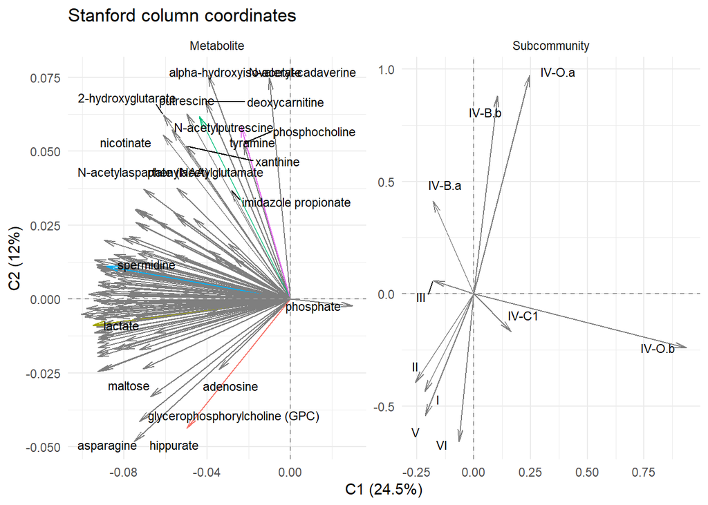

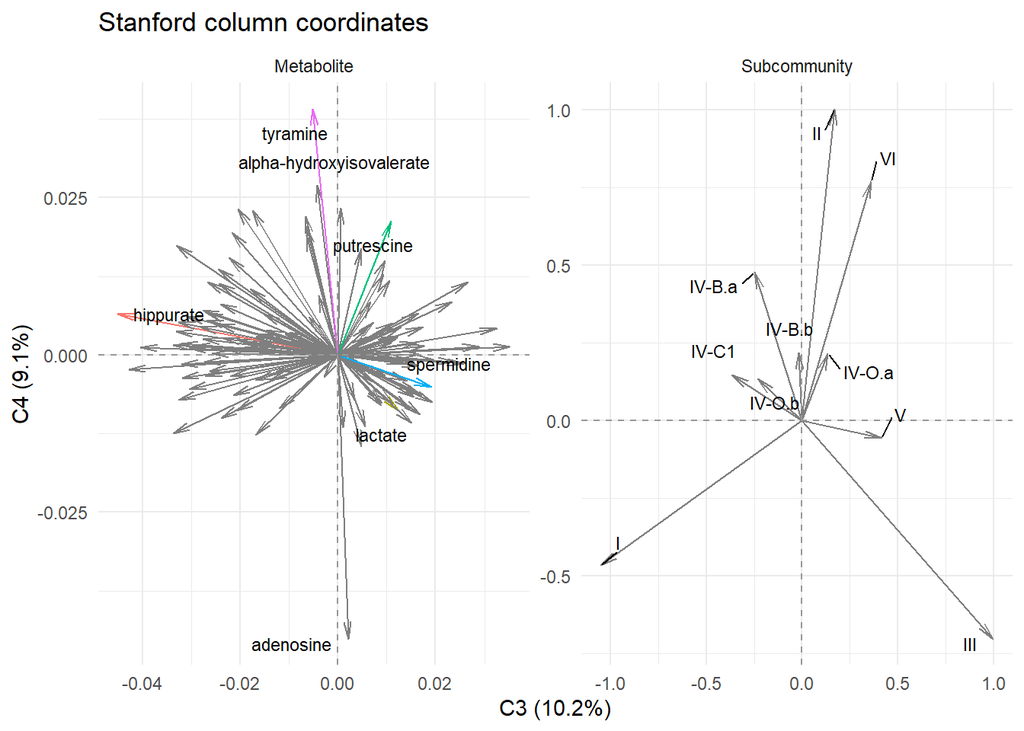

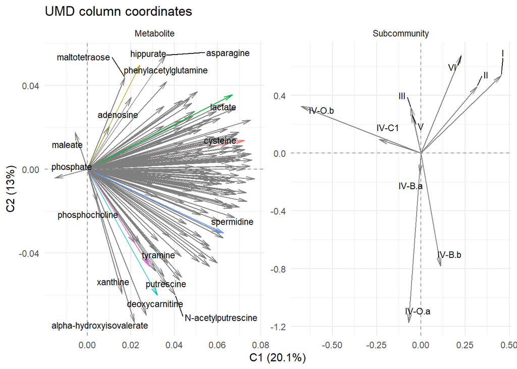

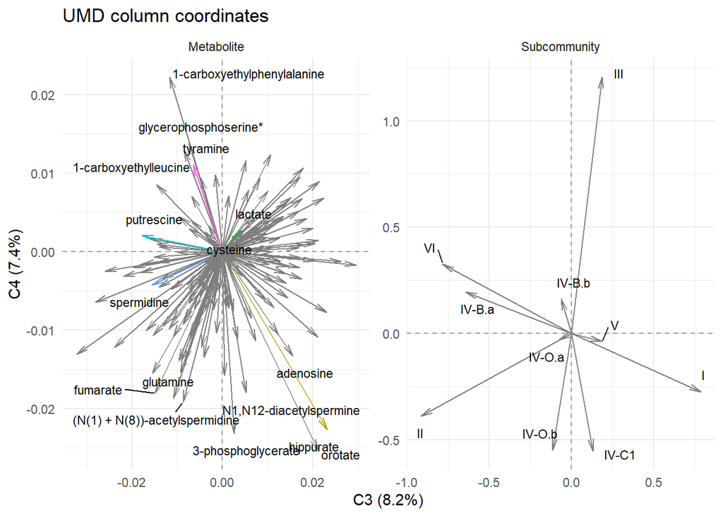

```r
Col.coord(statis = statis.stan, comp = c(1,2), eigentable.stan, palette = Dcol$Stanford, cohort = "Stanford")
Col.coord(statis = statis.stan, comp = c(3,4), eigentable.stan, palette = Dcol$Stanford, cohort = "Stanford")
Col.coord(statis = statis.umd, comp = c(1,2), eigentable.umd, palette = Dcol$UMD, cohort = "UMD")
Col.coord(statis = statis.umd, comp = c(3,4), eigentable.umd, palette = Dcol$UMD, cohort = "UMD")
```

```r
tibble(variab = rownames(statis.stan$C.Co),
       data.frame(statis.stan$C.Co),
       block = statis.stan$TC$T) |>
  mutate(evid = ifelse(variab %in% c("lactate", "tyramine", "putrescine", "spermidine", "cystein", "hippurate"), variab, NA)) |>
  mutate(varlab = ifelse(!(variab %in% c("lactate", "tyramine", "putrescine", "spermidine", "cystein", "hippurate")), variab, NA)) |>
  dplyr::select(evid, varlab) |> tail()
  ggplot()+
  geom_segment(aes(xend = C1, yend = C2, x=0,y=0, col = evid))+
  ggrepel::geom_text_repel(aes(x = C1, y = C2, label = variab),
                           box.padding = 0.5)+
  ggrepel::geom_text_repel(aes(x = C1, y = C2, label = evid),
                           box.padding = 0.5)+
  facet_wrap(facets=vars(block), scales = "free")
```

In Stanford:

- Metabolites: metabolites are all negatively correlated to the first compromise axis. Hippurate stands out as it is the metabolite most correlated with the second PC. Tyramine is poorly correlated to either axis 1 and 2.
- Subcommunity: textit{Lactobacillus}-dominated subcommunities, as opposed to non-textit{Lactobacillus}-dominated subcommunities, are all negatively correlated to the first axis, with subcommunity I () and III () being the most predominant variables. These two variables probably have a great influence on the positionning of the individuals in the compromise subspace. CST III and I are close together on dimensions 3 and 4 and are orthogonal to IV-O.a and IV-O.b.
- Both: Hippurate is aligned with the first subcommunity “CST I”, indicating a correlation between these two elements. Lactate, as expected, is negatively correlated with the first axis, along with all textit{Lactobacillus}-dominated subcommunities. Tyramine, putrescine, and N-acetyl-cadaverine are associated with CST IV-0.a in the third and forth dimensions.

In UMD

- Metabolites: hippurate stands out a little, compared to lactate and spermidine which are in the confounded in the crowd of vectors. Tyramine also stands out a little with its correlation to the second axis, like putrescine.
- Subcommunity: the lactobacilli subcommunities are more negatively correlated to the first axis than the non-lactobacilli ones. CST-I and IV-O.a contribute most to the first and second axis respectively.
- both: hippurate is correlated to CST-I, along with some other metabolites like asparagine. Xanthine, tyramine, and putrescine might be the most correlated metabolites with CST IV-O.a

```r
#Manual STATIS
MB <- t(t(MB.stan)*sqrt(apply(MB.stan, 2, FUN = sd)))
VM <- t(t(VM.stan)*sqrt(apply(VM.stan, 2, FUN = sd)))
MB <- MB.stan
VM <- VM.stan

Smb <- as.matrix(MB) %*% t(as.matrix(MB))
Ssc <- as.matrix(VM) %*% t(as.matrix(VM))

S <- matrix(unlist(list(Smb, Ssc)), 191*191, 2)
RVraw <- t(S) %*% S
ak <- sqrt(diag(RVraw))

RV <- statis.stan$RV
eig <- eigen(RV)$vector

C <- (eig[1,1]/ak[1])*Smb + (eig[2,1]/ak[2])*Ssc
dim(C)

PCA <- FactoMineR::PCA(X = C, scale = FALSE, graph = FALSE)
fviz_eig(PCA, ncp = 30)
fviz_pca_ind(PCA, axes = c(1,2), label = "none")
ggplot(statis.stan$C.li)+
  aes(x = C1, y = C2)+
  geom_point()+
  geom_vline(aes(xintercept = 0),
             linetype = "dashed", col = "grey60")+
  geom_hline(aes(yintercept = 0),
             linetype = "dashed", col = "grey60")+
  labs(subtitle = paste0("Stanford", " compromise"),
       col = "Lactobacillus \n proportion")
Score <- PCA$ind$coord

LoadM <- t(MB.stan) %*% Score
LoadS <- t(VM.stan) %*% Score
ggplot()+
  geom_segment(aes(xend = LoadS[,1], yend = LoadS[,2],
                   x = 0, y = 0))
ggplot()+
  geom_segment(aes(xend = LoadM[,1], yend = LoadM[,2],
                   x = 0, y = 0))
```

```r
rm(C, cca.stan, cca.umd, Comb, eigentable.stan, eigentable.umd, LoadM, LoadS, loads1, loads2, PCA, Score, Smb, Ssc, var.tib.stan, var.tib.umd, X.stan, X.umd, Y.stan, Y.umd)
# MANUALLY CHECKING ade4::statis FUNCTION
## Inputs
X <- ktabs.stan
scannf = TRUE
nf = 3
tol = 1e-07
##########
## PART I
if (!inherits(X, "ktab"))
    stop("object 'ktab' expected")
lw <- X$lw
nlig <- length(lw)
cw <- X$cw
ncol <- length(cw)
ntab <- length(X$blo)
indicablo <- X$TC[, 1]
tab.names <- tab.names(X)
auxinames <- ktab.util.names(X)
statis <- list()
sep <- list()
lwsqrt <- sqrt(lw)
##########
## PART II
for (k in 1:ntab) {
    ak <- sqrt(cw[indicablo == levels(X$TC[, 1])[k]])
    wk <- as.matrix(X[[k]]) * lwsqrt
    wk <- t(t(wk) * ak)
    wk <- wk %*% t(wk)
    sep[[k]] <- wk
}
sep <- matrix(unlist(sep), nlig * nlig, ntab)
RV <- t(sep) %*% sep
ak <- sqrt(diag(RV))
RV <- sweep(RV, 1, ak, "/")
RV <- sweep(RV, 2, ak, "/")
dimnames(RV) <- list(tab.names, tab.names)
statis$RV <- RV
###########
## PART III.a
eig1 <- eigen(RV, symmetric = TRUE)
statis$RV.eig <- eig1$values
if (any(eig1$vectors[, 1] < 0))
    eig1$vectors[, 1] <- -eig1$vectors[, 1]
tabw <- eig1$vectors[, 1]
statis$RV.tabw <- tabw
###########
## PART III.b
w <- t(t(eig1$vectors) * sqrt(eig1$values))
w <- as.data.frame(w)
row.names(w) <- tab.names
names(w) <- paste("S", 1:ncol(w), sep = "")
statis$RV.coo <- w[, 1:min(4, ncol(w))]
###########
## PART IV.a
sep <- t(t(sep)/ak)
#C.ro <- rowSums(sweep(sep, 2, tabw, "*"))
C.ro <- rowSums(sweep(sep, 2, tabw, "*"))
C.ro <- matrix(unlist(C.ro), nlig, nlig)
###########
## PART IV.b
eig1 <- eigen(C.ro, symmetric = TRUE)
rm(C.ro)
eig <- eig1$values
rank <- sum((eig/eig[1]) > tol)
if (scannf) {
    barplot(eig[1:rank])
    cat("Select the number of axes: ")
    nf <- as.integer(readLines(n = 1))
    messageScannf(match.call(), nf)
}
if (nf <= 0)
    nf <- 2
if (nf > rank)
    nf <- rank
statis$C.eig <- eig[1:rank]
statis$C.nf <- nf
statis$C.rank <- rank
###########
## PART IV.c
wref <- eig1$vectors[, 1:nf]
rm(eig1)
wref <- wref/lwsqrt
w <- data.frame(t(t(wref) * sqrt(eig[1:nf])))
row.names(w) <- row.names(X)
names(w) <- paste("C", 1:nf, sep = "")
statis$C.li <- w
##########
## PART V
w <- as.matrix(X[[1]])
for (k in 2:ntab) {
    w <- cbind(w, as.matrix(X[[k]]))
}
w <- w * lw
w <- t(w) %*% wref
w <- data.frame(w, row.names = auxinames$col)
names(w) <- paste("C", 1:nf, sep = "")
statis$C.Co <- w
```

```r
##########
## PART VI
sepanL1 <- sepan(X, nf = 4)$L1
w <- matrix(0, ntab * 4, nf)
i1 <- 0
i2 <- 0
for (k in 1:ntab) {
    i1 <- i2 + 1
    i2 <- i2 + 4
    tab <- as.matrix(sepanL1[X$TL[, 1] == levels(X$TL[, 1])[k],
        ])
    tab <- t(tab * lw) %*% wref
    for (i in 1:min(nf, 4)) {
        if (tab[i, i] < 0) {
            for (j in 1:nf) tab[i, j] <- -tab[i, j]
        }
    }
    w[i1:i2, ] <- tab
}
w <- data.frame(w, row.names = auxinames$tab)
names(w) <- paste("C", 1:nf, sep = "")
statis$C.T4 <- w
w <- as.matrix(statis$C.li) * lwsqrt
w <- w %*% t(w)
w <- w/sqrt(sum(w * w))
w <- as.vector(unlist(w))
sep <- sep * unlist(w)
w <- apply(sep, 2, sum)
statis$cos2 <- w
###########
## PART VII
statis$tab.names <- tab.names
statis$TL <- X$TL
statis$TC <- X$TC
statis$T4 <- X$T4
class(statis) <- "statis"
return(statis)
#End of ade4::statis
```

```r
rm(eigentable.stan, eigentable.umd, ktabs.stan, ktabs.umd, res.stan, res.umd, statis.stan, statis.umd)
```

## 2.2 Simultaneous Component Analysis

### 2.2.1 Theory

Simultaneous component analysis (SCA) is very similar to STATIS method. It was originally designed to compare different groups of individuals on which one had measured the same set of variables. However, it has been adapted to study datasets of different set of variables on the same group of individuals. [multibloc::sca](https://cran.r-project.org/web/packages/multiblock/multiblock.pdf)

The idea is still to perform a PCA on a weighted average of all similarity matrices $[S_k]_{k=1,...,K}$, but the weights are evenly distributed. [othersource](https://ppw.kuleuven.be/okp/_pdf/DeRoover2012CSCAF.pdf) [url](https://link.springer.com/article/10.3758/s13428-011-0129-1). [dissertation](https://pure.rug.nl/ws/portalfiles/portal/22324119/Complete_dissertation.pdf). In that sense, the objective of the SCA is to optimize the following criterion:

$$\arg \min_{T, P_k} \sum_{k=1}^{K} \|X_k
- TP_k'\|^2$$

One may compare it with the optimization problem of the STATIS method and notice that the weights $W^{(1)}$ are missing in SCA. That is because the weights are all the same in SCA.

NOT SURE ABOUT THE FOLLOWING PARAGRAPH The scores being common to each dataset, the loadings become very interesting as they could potentially translate the correlations between $X_1$ and $X_2$ (i.e. the metabolite and composition data). Therefore, the simultaneous component analysis of common-row datasets is the study of the component loadings shared by the datasets. [OverviewOfSCA](https://doi.org/10.1186/1471-2105-10-246) [ASCA](https://doi.org/10.1093/bioinformatics/bti476).

This analysis requires our two datasets on metabolites and compositional data. They must be formatted in such a way that the samples appear in rows and the features in columns. Moreover, the sample names must be matching. This matching process also mean loss of information because we performed sample filtering in the metabolite preprocessing section.

### 2.2.2 Variance decomposition

Here are the different objects from the SC analysis using function from package along with a summary of the model (the datatables are scaled for the analysis):

```r
sca.stan <- multiblock::sca(X = list(as.data.frame(MB.stan),
                                     as.data.frame(VM.stan)),
                            ncomp = nvar, scale = F,
                            samplelinked = T)
sca.umd <- multiblock::sca(X = list(MB.umd, VM.umd), ncomp = nvar, scale = F, samplelinked = T)
#Summary of SCA model
summary(sca.stan)
summary(sca.umd)
```

```
## Simultaneous Component Analysis
## ===============================
##
## $scores: Common scores (191x50)
## $blockLoadings: Block loadings:
## - (132x50), (10x50)
## Simultaneous Component Analysis
## ===============================
##
## $scores: Common scores (200x50)
## $blockLoadings: Block loadings:
## - (165x50), (10x50)
```

Just like PCA, we can inspect the (global) explained variance of the simultaneous components:

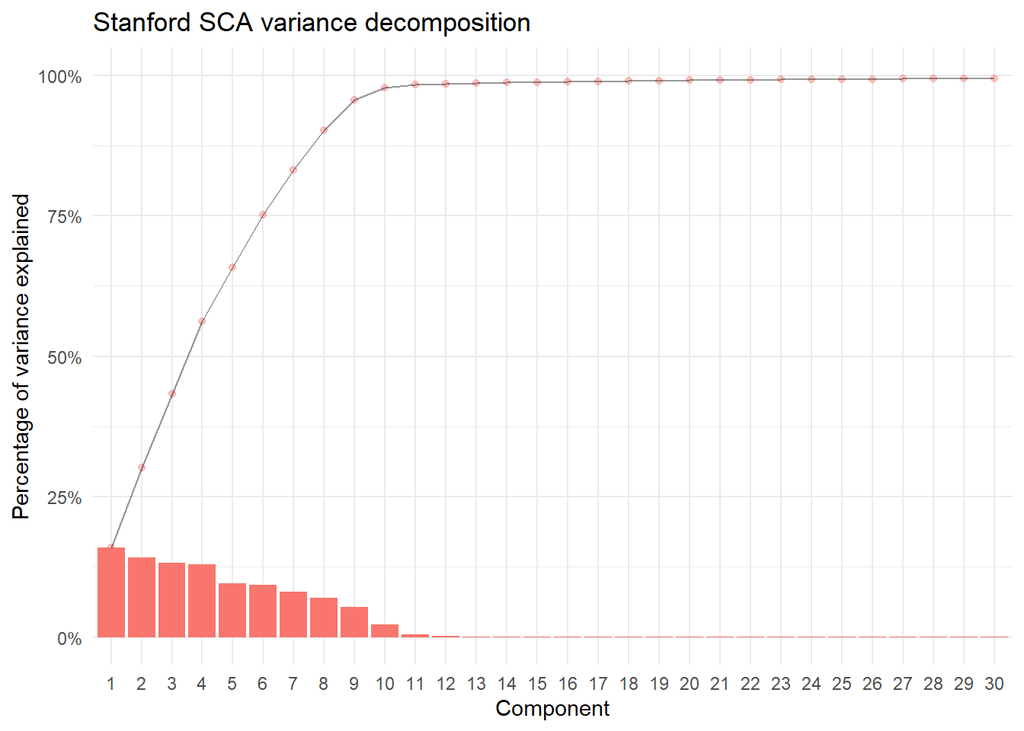

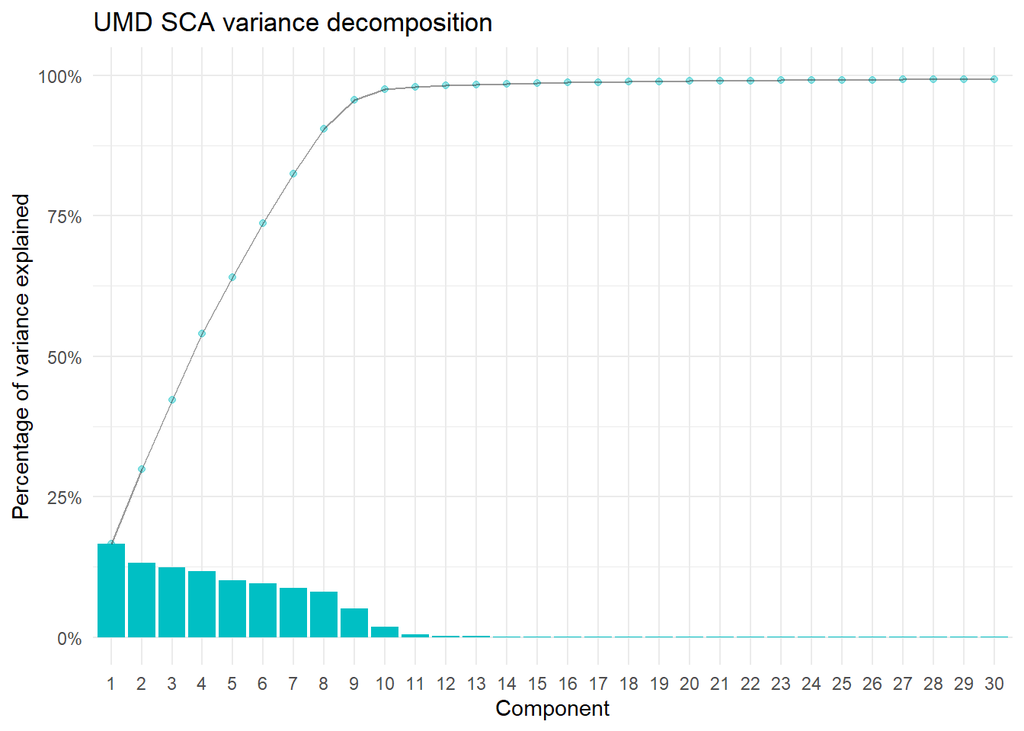

```r
var.tib.stan <-
  tibble(comp = names(sca.stan$explvar),
         perc.var = sca.stan$explvar/100) |>
  mutate(cum = cumsum(perc.var))
var.tib.umd <-
  tibble(comp = names(sca.umd$explvar),
         perc.var = sca.umd$explvar/100) |>
  mutate(cum = cumsum(perc.var))
vardecomp(var.tib.stan, cohort = "Stanford", comp.max = 30, col = CohCol["Stanford"])
vardecomp(var.tib.umd, cohort = "UMD", comp.max = 30, col = CohCol["UMD"])
```

### 2.2.3 Scores

Let us quickly explore the common scores of the SCA model:

```r
#Selecting 10 random subjects
set.seed(1234)
subj.stan <- sample(x = unique(MB.SE.stan$Subject), size = 10, replace = FALSE)
Sampled.stan <- c()
  for(i in 1:length(MB.SE.stan$Subject)){
    if(MB.SE.stan$Subject[i] %in% subj.stan){
      Sampled.stan[i] <- MB.SE.stan$Subject[i]
    } else{Sampled.stan[i] <- "(other)"}
  }
subj.umd <- sample(x = unique(MB.SE.umd$Subject), size = 10, replace = FALSE)
Sampled.umd <- c()
  for(i in 1:length(MB.SE.umd$Subject)){
    if(MB.SE.umd$Subject[i] %in% subj.umd){
      Sampled.umd[i] <- MB.SE.umd$Subject[i]
    } else{Sampled.umd[i] <- "(other)"}
  }
#Color palette
palette <- c("grey80",
             "#1F77B4", "#FF7F0E", "#2CA02C", "#D62728", "#9467BD",
             "#8C564B", "#E377C2", "#00BC00", "#BCBD22", "#17BECF")
```

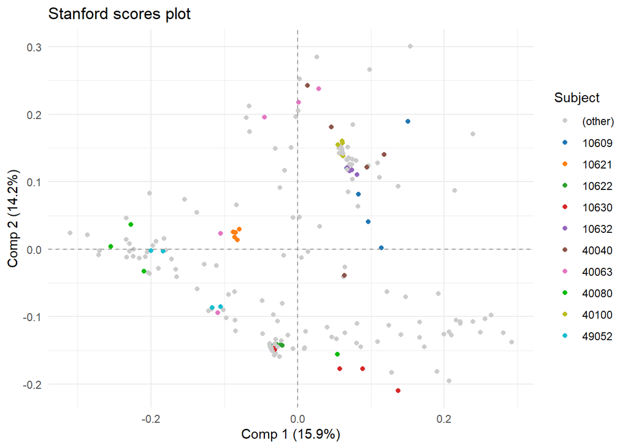

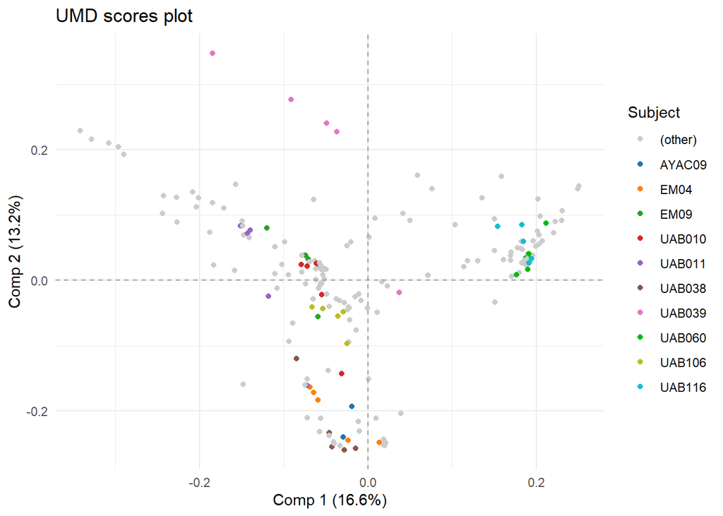

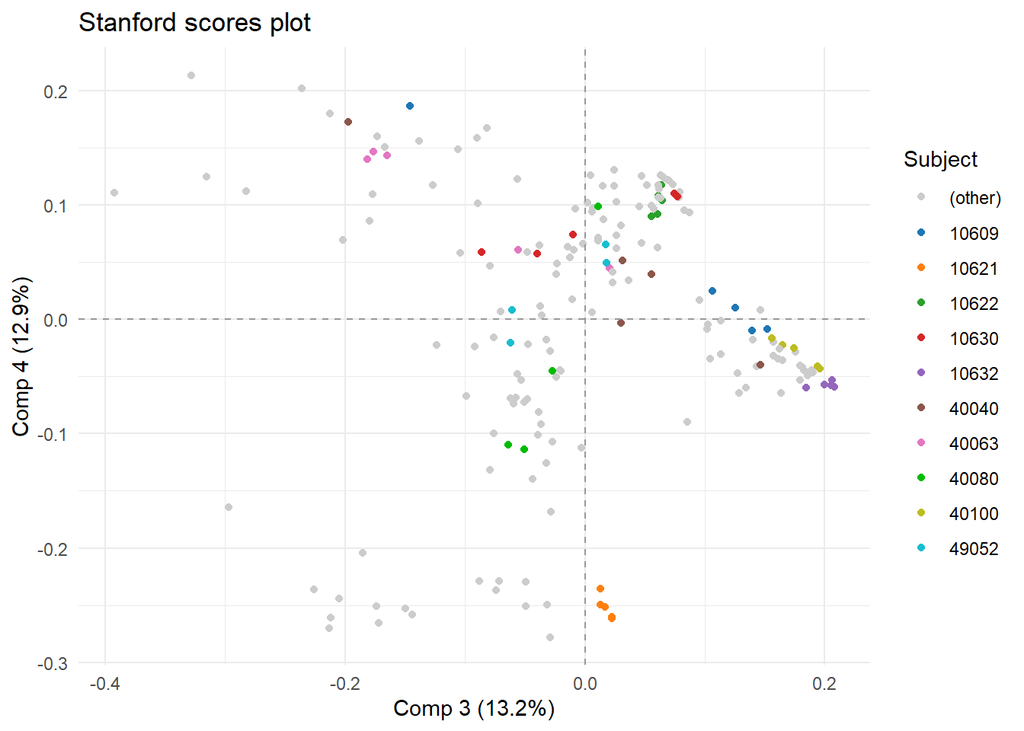

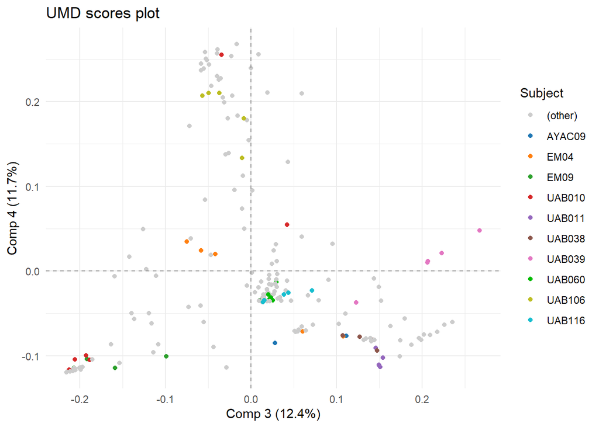

```r
#Component 1 and 2 scores
scores.plot(sca.mod = sca.stan, comp = c(1,2), cohort = "Stanford")+
  aes(col = Sampled.stan)+
  scale_fill_manual(values = palette, aesthetics = c("colour", "fill"))+
  labs(col = "Subject")

scores.plot(sca.mod = sca.umd, comp = c(1,2), cohort = "UMD")+
  aes(col = Sampled.umd)+
  scale_fill_manual(values = palette, aesthetics = c("colour", "fill"))+
  labs(col = "Subject")

#Component 3 and 4 scores
scores.plot(sca.mod = sca.stan, comp = c(3,4), cohort = "Stanford")+
  aes(col = Sampled.stan)+
  scale_fill_manual(values = palette, aesthetics = c("colour", "fill"))+
  labs(col = "Subject")
scores.plot(sca.mod = sca.umd, comp = c(3,4), cohort = "UMD")+
  aes(col = Sampled.umd)+
  scale_fill_manual(values = palette, aesthetics = c("colour", "fill"))+
  labs(col = "Subject")
```

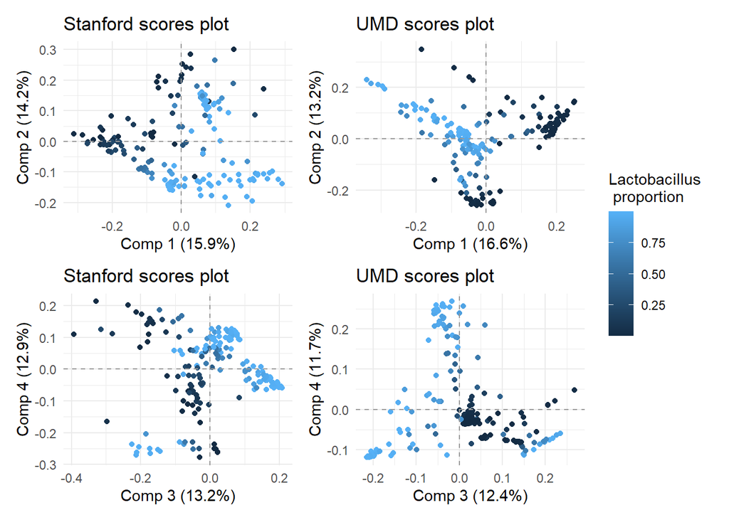

```r
scores.plot(sca.mod = sca.stan, comp = c(1,2), cohort = "Stanford")+
  aes(col = MB.SE.stan$Prop_Lacto)+
  labs(col = "Lactobacillus \n proportion") +
scores.plot(sca.mod = sca.umd, comp = c(1,2), cohort = "UMD")+
  aes(col = MB.SE.umd$Prop_Lacto)+
  labs(col = "Lactobacillus \n proportion") +
scores.plot(sca.mod = sca.stan, comp = c(3,4), cohort = "Stanford")+
  aes(col = MB.SE.stan$Prop_Lacto)+
  labs(col = "Lactobacillus \n proportion") +
scores.plot(sca.mod = sca.umd, comp = c(3,4), cohort = "UMD")+
  aes(col = MB.SE.umd$Prop_Lacto)+
  labs(col = "Lactobacillus \n proportion") +
  plot_layout(guides = "collect", axes = "collect", ncol = 2)

rm(i, palette, Sampled.stan, Sampled.umd, subj.stan, subj.umd)
```

If we look at the coloring, we can see some subjects for which the data points are closer together, suggesting a small subject effect or within subject correlation.

### 2.2.4 Loadings

Let us explore the loadings. First, let us seem them separately for each data block (i.e. for MB and sub-community data) and then visualize them together in correlation circle plot:

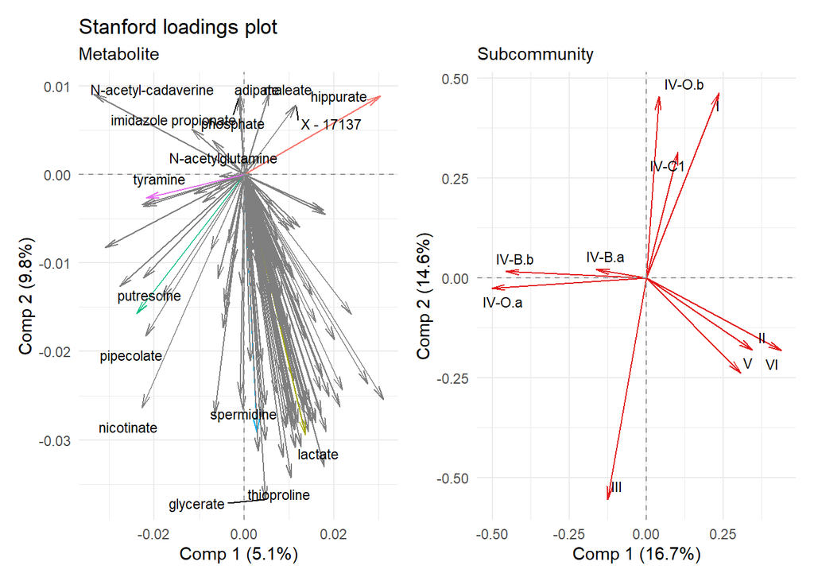

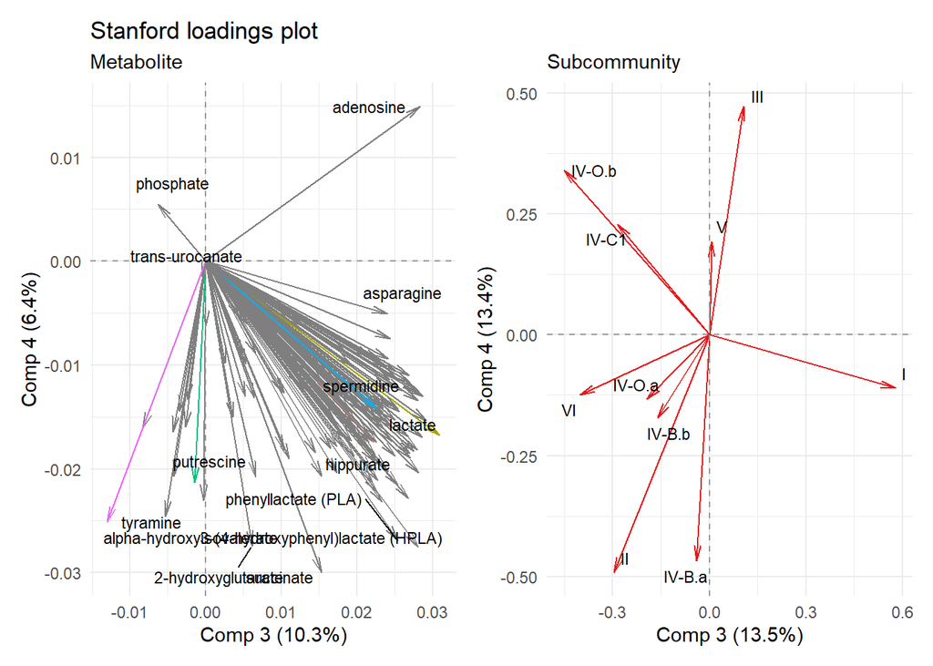

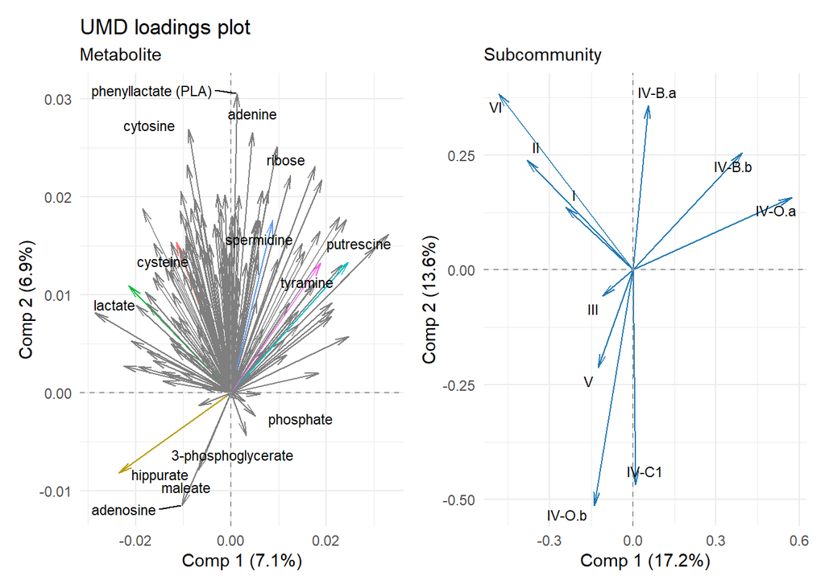

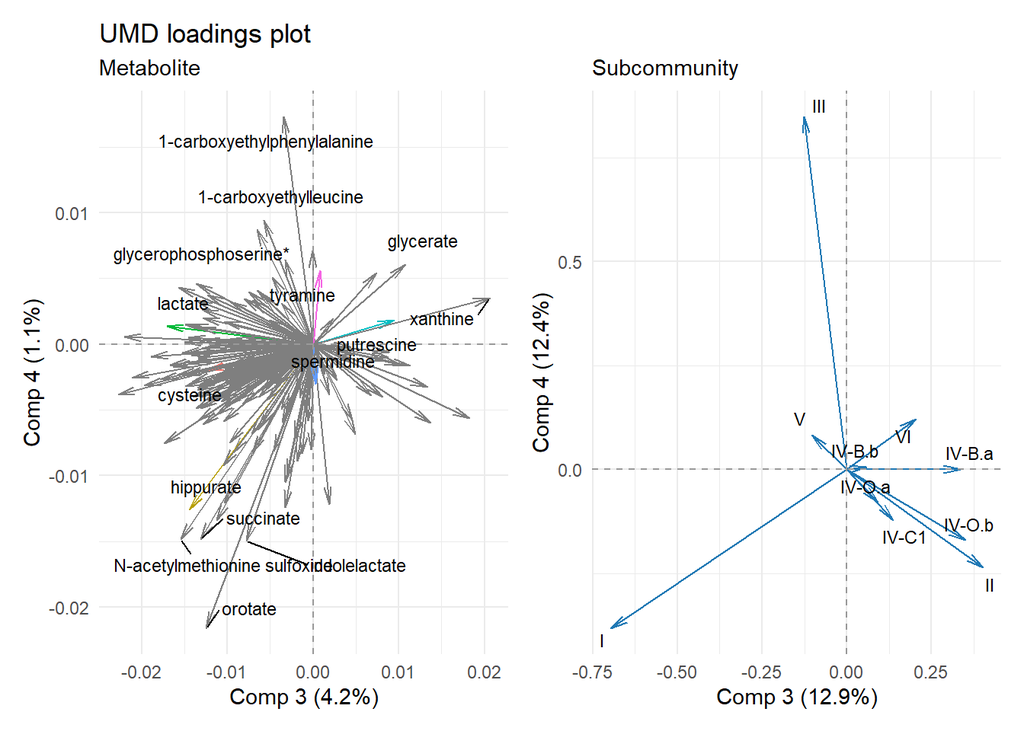

```r
loading.plot(sca.mod = sca.stan, comp = c(1,2), palette = Dcol$Stanford, cohort = "Stanford")
loading.plot(sca.mod = sca.stan, comp = c(3,4), palette = Dcol$Stanford, cohort = "Stanford")
loading.plot(sca.mod = sca.umd, comp = c(1,2), palette = Dcol$UMD, cohort = "UMD")
loading.plot(sca.mod = sca.umd, comp = c(3,4), palette = Dcol$UMD, cohort = "UMD")
```

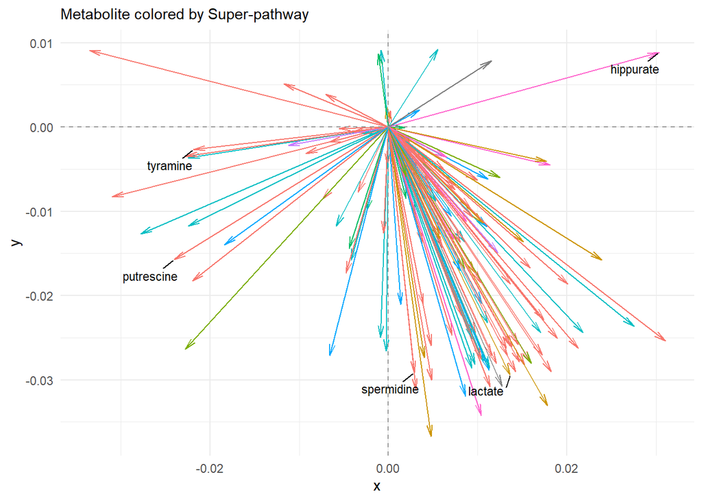

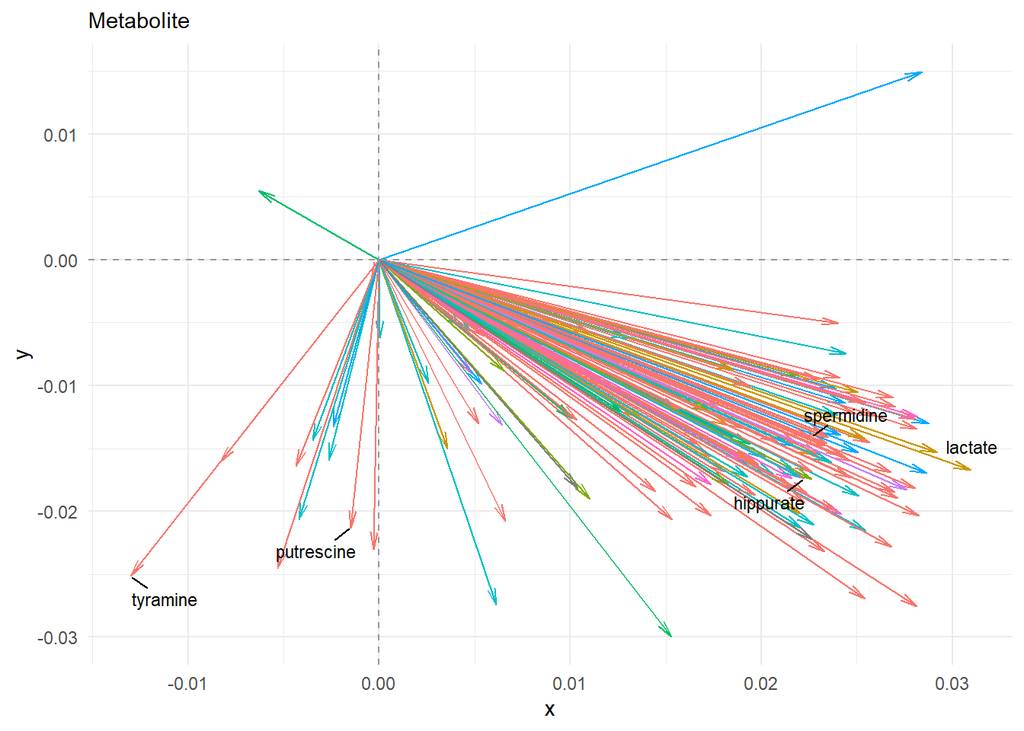

```r
loads1 <- sca.stan$blockLoadings[[1]]
loads2 <- sca.stan$blockLoadings[[2]]

data.frame(block = "Metabo",
               variab = rownames(loads1),
               loads1) |> tibble() |>
    mutate(evid = ifelse(variab %in% c("lactate", "tyramine", "putrescine", "spermidine", "cysteine", "hippurate"), variab, NA)) |>
    mutate(varlab = ifelse(!(variab %in% c("lactate", "tyramine", "putrescine", "spermidine", "cysteine", "hippurate")), variab, NA)) |>
    ggplot()+
    geom_segment(aes(xend = Comp.1, yend = Comp.2, x=0,y=0,
                     col = rowData(MB.SE.stan)$SUPER_PATHWAY),
                 arrow = arrow(angle = 12, length = unit(0.3, "cm")))+
    geom_vline(aes(xintercept = 0),
               linetype = "dashed", col = "grey60")+
    geom_hline(aes(yintercept = 0),
               linetype = "dashed", col = "grey60")+
    labs(subtitle = "Metabolite colored by Super-pathway")+
    #ggrepel::geom_text_repel(aes(x = Comp.1, y = Comp.2, label = varlab), box.padding = 0.5, size = 3)+
    ggrepel::geom_text_repel(aes(x = Comp.1, y = Comp.2, label = evid), box.padding = 0.5, size = 3)+
    theme(legend.position= "none")

data.frame(block = "Metabo",
               variab = rownames(loads1),
               loads1) |> tibble() |>
    mutate(evid = ifelse(variab %in% c("lactate", "tyramine", "putrescine", "spermidine", "cysteine", "hippurate"), variab, NA)) |>
    mutate(varlab = ifelse(!(variab %in% c("lactate", "tyramine", "putrescine", "spermidine", "cysteine", "hippurate")), variab, NA)) |>
    ggplot()+
    geom_segment(aes(xend = Comp.3, yend = Comp.4, x=0,y=0,
                     col = rowData(MB.SE.stan)$SUPER_PATHWAY),
                 arrow = arrow(angle = 12, length = unit(0.3, "cm")))+
    geom_vline(aes(xintercept = 0),
               linetype = "dashed", col = "grey60")+
    geom_hline(aes(yintercept = 0),
               linetype = "dashed", col = "grey60")+
    labs(subtitle = "Metabolite")+
    #ggrepel::geom_text_repel(aes(x = Comp.1, y = Comp.2, label = varlab), box.padding = 0.5, size = 3)+
    ggrepel::geom_text_repel(aes(x = Comp.3, y = Comp.4, label = evid), box.padding = 0.5, size = 3)+
    theme(legend.position= "none")
```

Stanford: